# USDRates

USD Reference Rates

```python
'''
this notebook will be converted to html with
        jupyter nbconvert --to html --no-input

for that reason all code comments are in the code cells

see here for the presentation
http://htmlpreview.github.io/?https://github.com/TheReallyBigApple/Public/blob/master/USDRatesPresentation.html



'''

import matplotlib as mpl
import matplotlib.pyplot as plt
import numpy as np
import pandas as pd
import datetime as dt
from IPython.display import HTML
```

```python
# This code ignores my certificate validation on the ny frb site, not clear why it throws errors sometimes

import os, ssl

if (not os.environ.get('PYTHONHTTPSVERIFY', '') and getattr(ssl, '_create_unverified_context', None)):
    ssl._create_default_https_context = ssl._create_unverified_context
```

```python
# python doesnt really have enums or constants. These create some readibility.
# these are static classes

class Product():
    EFFR = 500
    OBFR = 505
    TGCR = 510
    BGCR = 515
    SOFR = 520
    SOFR_AVGS = 525
    LIBOR_3M = 100,
    LIBOR_1M = 110

class Constant():
    product_code="50"
    format="csv"
    path=r'C:\Users\arono\source\python\quandl\\'
    ny_frb_base_url="https://markets.newyorkfed.org/read?startDt="
    stl_frb_base_url="https://fred.stlouisfed.org/graph/fredgraph.csv?"


    ProductStr = {
        Product.EFFR: "EFFR",
        Product.OBFR: "OBFR",
        Product.BGCR: "BGCR",
        Product.TGCR: "TGCR",
        Product.SOFR: "SOFR",
        Product.LIBOR_1M: "1M LIBOR",
        Product.LIBOR_3M: "3M LIBOR"
    }
```

```python
# static class to do all the plotting

class Plot():

        # note the axes is passed as a reference so no need to return anything
    def setup_axes(ax, productStr=""):
        yearsLoc = mpl.dates.YearLocator()
        monthsLoc = mpl.dates.MonthLocator(interval=2)     # every 2 months
        ax.xaxis.set_major_locator(yearsLoc)    # big ticks for labels
        ax.xaxis.set_minor_locator(monthsLoc)
        xFmt = mpl.dates.DateFormatter('%Y')
        if (productStr !=""):
            ax.set_title(productStr + ': Past 4 Years',fontsize=15, fontweight='bold', color='blue',pad=40)
        ax.xaxis.set_major_formatter(xFmt)   # format labels on big ticks
        ax.set(ylabel="Rate (%)", xlabel='')
        ax.set_ylim(-.1,4)


    def one(frb1):
        print("\n\n")
        fig = plt.figure(figsize=(11,8))
        ax = fig.add_subplot(111)
        ax.plot_date(frb1.data_frame.date, frb1.data_frame.rate, linestyle='-', marker=' ')
        Plot.setup_axes(ax,frb1.get_productStr())
        plt.show()
        print("\n\n")



    def two(frb1,frb2):
        print("\n\n")
        fig = plt.figure(figsize=(11,8))
        supTitleStr=frb1.get_productStr() + "/" + frb2.get_productStr() + " past 4 years"
        plt.suptitle(supTitleStr, fontsize=15, fontweight='bold', color='blue', y=1.05)  # y is for padding
        ax = fig.add_subplot(111)
        ax.plot_date(frb1.data_frame.date, frb1.data_frame.rate, linestyle='-', marker=' ', label=frb1.get_productStr())
        ax.plot_date(frb2.data_frame.date, frb2.data_frame.rate, linestyle='-', marker=' ', label=frb2.get_productStr())
        Plot.setup_axes(ax)
        plt.legend()
        plt.show()
        print("\n\n")





    def four(frb1,frb2, frb3, frb4):
        bbox_args = dict(boxstyle="round", fc="0.8")
        arrow_args = dict(arrowstyle="->")


        print("\n\n")
        fig = plt.figure(figsize=(15,10))
        supTitleStr="USD Benchmark Rates : Past 4 years"
        plt.suptitle(supTitleStr, fontsize=18, fontweight='bold', color='blue', y=1.01)  # y is for padding
        ax = fig.add_subplot(111)
        ax.plot_date(frb1.data_frame.date, frb1.data_frame.rate, linestyle='solid', marker=' ',
                     label=frb1.get_productStr())
        ax.plot_date(frb2.data_frame.date, frb2.data_frame.rate, linestyle='dashed', marker=' ',
                     label=frb2.get_productStr())
        ax.plot_date(frb3.data_frame.date, frb3.data_frame.rate, linestyle='dashdot', marker=' ',
                     label=frb3.get_productStr())
        ax.plot_date(frb4.data_frame.date, frb4.data_frame.rate, linestyle='dotted', marker=' ',
                     label=frb4.get_productStr())
        Plot.setup_axes(ax)
        plt.legend(fontsize=14,borderpad=2)

        # with dates, data may not work, use "axes fraction"
        # xy is where the arrow points to
        # xytext is where the text goes and where the arrow starts
        # size and weight refer to the text

        ax.annotate("SOFR Surge Events", xy=(.44, .95), xycoords='axes fraction', xytext=(.55, 0.8), textcoords='axes fraction',
                         bbox=dict(boxstyle="round4,pad=1.1",  fc=(1.0, 0.7, 0.7),ec=(1., .5, .5)),
                         size=12,weight='heavy',
                         arrowprops=dict(arrowstyle="->", color="red", lw=2,  connectionstyle=("arc3,rad=0."))
                   )




        ax.annotate("FED Pandemic\nResponse", xy=(.55, .4), xycoords='axes fraction', xytext=(.7, 0.3), textcoords='axes fraction',
                         bbox=dict(boxstyle="round4,pad=1.1",
                              fc=(1.0, 0.7, 0.7),
                              ec=(1., .5, .5)),
                         size=12, weight='heavy',
                         arrowprops=dict(arrowstyle="->", color="red", lw=2,
                         connectionstyle=("arc3,rad=0.")))


        ax.annotate("Month End\nDrops", xy=(.062, .37), xycoords='axes fraction', xytext=(.1, 0.15), textcoords='axes fraction',
                         bbox=dict(boxstyle="round4,pad=1.1", fc=(1.0, 0.7, 0.7),ec=(1., .5, .5)),
                        size=12, weight='heavy',
                         arrowprops=dict(arrowstyle="->", color="red", lw=2,
                         connectionstyle=("arc3,rad=0.")))



        plt.show()
        print("\n\n")


    def two_side_by_side(frb1,frb2):
        print("\n\n")
        fig, ax = plt.subplots(1, 2, figsize=(15, 7))
        supTitleStr=frb1.get_productStr() + "/" + frb2.get_productStr() + " past 4 years"
        plt.suptitle(supTitleStr, fontsize=15, fontweight='bold', color='blue', y=1.05)  # y is for padding
        ax[0].plot_date(frb1.data_frame.date, frb1.data_frame.rate, linestyle='-', marker=' ')
        ax[1].plot_date(frb2.data_frame.date, frb2.data_frame.rate, linestyle='-', marker=' ')
        ax[1].get_yaxis().set_visible(False)
        Plot.setup_axes(ax[0], frb1.get_productStr())
        Plot.setup_axes(ax[1], frb2.get_productStr())
        plt.show()
        print("\n\n")
```

```python
# Class to interface with the New York Fed web service

class NY_FRB():
    def __init__(self,product=Product.SOFR, startd="2018-01-01", endd="2022-12-31"):
        self.product=product
        self.startd=startd
        self.endd=endd

        self.data_frame=pd.DataFrame()


    def get_productStr(self):
        return Constant.ProductStr[self.product]



    def create_url(self):
        date_range=self.startd+"&endDt="+self.endd+"&"
        codes="eventCodes="+str(self.product)+"&"+"productCode="+Constant.product_code
        # the 1 in postDt:1 is ascending, -1 is descending
        post_url="&sort=postDt:1,eventCode:1&format="+Constant.format
        url=Constant.ny_frb_base_url+date_range+codes+post_url
        return url


    def get_data(self):
        url=self.create_url()
        self.data_frame=pd.read_csv(url)
        self.save_data()
        self.data_frame = self.data_frame.rename(columns={'Effective Date': 'date'})
        self.data_frame = self.data_frame.rename(columns={'Rate (%)': 'rate'})
        self.data_frame = self.data_frame.rename(columns={ 'Volume ($Billions)': 'volume'})
        self.data_frame = self.data_frame[["date", "rate","volume"]]
        # self.data_frame=self.data_frame[::-1].reset_index(drop=True)   # reverse the order
        self.data_frame.date=pd.to_datetime(self.data_frame['date'], format = '%m/%d/%Y')

    def query_data(self, start_date, end_date):
        mask = (self.data_frame['date'] > start_date) & (self.data_frame['date'] <= end_date)
        display(HTML(self.data_frame.loc[mask].to_html(index=False)))


    def save_data(self):
        file_name=Constant.path+Constant.ProductStr[self.product]+".csv"
        self.data_frame.to_csv(file_name)
```

```python
# Class to interface with the St Louis Fed web service

#    https://fred.stlouisfed.org/graph/fredgraph.csv?id=USD3MTD156N
#    https://fred.stlouisfed.org/graph/fredgraph.csv?id=USD1MTD156N

class STL_FRB():
    def __init__(self,product=Product.LIBOR_3M, startd="2018-01-01", endd="2022-12-31"):
        self.product=product
        self.startd=startd
        self.endd=endd


    def get_productStr(self):
        return Constant.ProductStr[self.product]



    def create_url(self):
        date_range=self.startd+"&endDt="+self.endd+"&"
        dates_url="cosd=" + self.startd + "&coed=" + self.endd

        if (self.product==Product.LIBOR_3M):
            product_url="id=USD3MTD156N"
        else:
            product_url="id=USD1MTD156N"

        url = Constant.stl_frb_base_url + "&" + dates_url + "&" + product_url
        return url


    def get_data(self):
        url=self.create_url()
        self.data_frame=pd.read_csv(url)
        self.save_data()
        self.data_frame = self.data_frame.rename(columns={'DATE': 'date'})
        self.data_frame = self.data_frame.rename(columns={'USD3MTD156N': 'rate'})
        self.data_frame = self.data_frame.rename(columns={'USD1MTD156N': 'rate'})
        self.data_frame = self.data_frame[["date", "rate"]]
        # self.data_frame=self.data_frame[::-1].reset_index(drop=True)   # reverse the order
        self.data_frame.date=pd.to_datetime(self.data_frame['date'], format = '%Y-%m-%d')
        self.data_frame.rate=pd.to_numeric(self.data_frame.rate, errors='coerce').fillna(0, downcast='infer')
        self.data_frame=self.data_frame[(self.data_frame["rate"]!=0)]

    def query_data(self, start_date, end_date):
        mask = (self.data_frame['date'] > start_date) & (self.data_frame['date'] <= end_date)
        display(HTML(self.data_frame.loc[mask].to_html(index=False)))


    def save_data(self):
        file_name=Constant.path+Constant.ProductStr[self.product]+".csv"
        self.data_frame.to_csv(file_name)
```

```python
#  retrieve all data first
frb_3M = STL_FRB(Product.LIBOR_3M)
frb_3M.get_data()

frb_1M = STL_FRB(Product.LIBOR_1M)
frb_1M.get_data()

frb_obfr = NY_FRB(Product.OBFR)
frb_obfr.get_data()

frb_effr = NY_FRB(Product.EFFR)
frb_effr.get_data()

frb_sofr = NY_FRB(Product.SOFR)
frb_sofr.get_data()
```

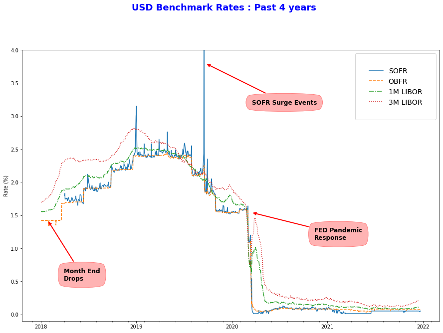

```python
Plot.four(frb_sofr, frb_obfr, frb_1M, frb_3M)
```

OBFR, SOFR and LIBOR are the 3 most important benchmark rates when borrowing US Dollars.

```
    Most Libor rates ceased to publish on December 2021, with the excpetion of the 1 and 3 month USD fixings
    which are scheduled to end on June 2023

    USD Libor is still in the process of being phased out, and many lenders continue to evaluate
    how to replace term USD libor rates with Alternative Refernce Rates.
```

**USD Alternative Reference Rates**

| rate | publisher | collateralized? |
| --- | --- | --- |
| EFFR | NY FRB | No |
| OBFR | NY FRB | No |
| SOFR | NY FRB | Yes |
| TGCR | NY FRB | Yes |
| BGCR | NY FRB | Yes |
| SOFR 1M Term | CME | Yes |
| SOFR 3M Term | CME | Yes |

OBFR and EFFR

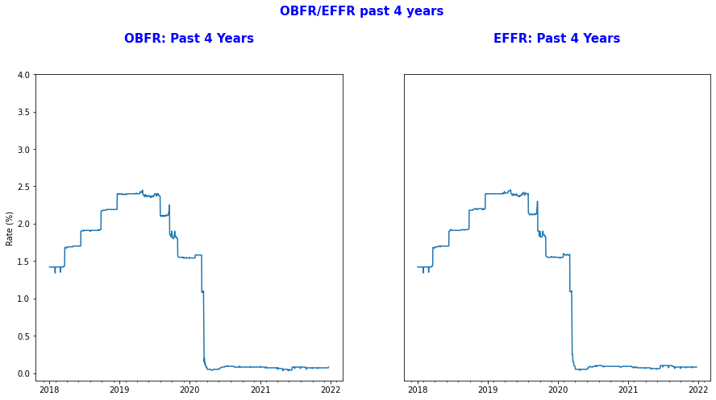

```python
Plot.two_side_by_side(frb_obfr,frb_effr)
```

As you can see, both rates trend almost identical. In fact they are almost identical.

EFFR is the median of all Federal Funds transactions, recorded on the previous day.

OBFR is the same but also incldues certain Eurodollar transactions, and certain domestic deposit transactions.

The data for both is from what depository institutions report in the [FR 2420 Report of Selected Money Market Rates](https://www.federalreserve.gov/apps/reportforms/reportdetail.aspx?sOoYJ+5BzDZiceJ/KVuLKQ==)

Since the median is taken and rounded to the nearest basis point, the rates will often be the same, and often will not change day to day.

For more information, refer to the FRB of NY web site for [EFFR](https://www.newyorkfed.org/markets/reference-rates/obfr) and [OBFR](https://www.newyorkfed.org/markets/reference-rates/obfr)

Both rates experienced a 1 day drop of 8 basis points on Jan 31, 2018 and Feb 28, 2018. Note what happened on Jan 31.

```python
frb_obfr.query_data('2018-01-26', '2018-02-2')
```

| date | rate | volume |
| --- | --- | --- |
| 2018-01-29 | 1.42 | 210 |
| 2018-01-30 | 1.42 | 218 |
| 2018-01-31 | 1.34 | 204 |
| 2018-02-01 | 1.42 | 224 |
| 2018-02-02 | 1.42 | 218 |

SOFR

The Secured Overnight Financing Rate (SOFR) is one of the 5 overnight, transaction based indexes that are expected to replace LIBOR as the benchmark for a wide range of financial products.

| rate | description | administrator | secured? |
| --- | --- | --- | --- |
| SOFR | Repo Market | NY FRB | Yes |
| ESTR | Euro bank borrowings | ECB | No |
| SONIA | Wide overnight market | BOE | No |
| SARON | Repo Market | SIX Swiss Exchange | Yes |
| TONA | Wide overngiht market | BOJ | No |

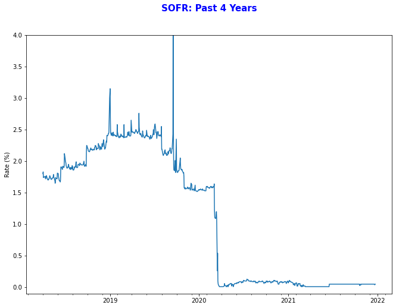

```python
Plot.one(frb_sofr)
```

Notice that SOFR has experienced some wild spikes in 2019. Note what happened on September 17

```python
frb_sofr.query_data('2019-09-12', '2019-09-20')
```

| date | rate | volume |
| --- | --- | --- |
| 2019-09-13 | 2.20 | 1134 |
| 2019-09-16 | 2.43 | 1156 |
| 2019-09-17 | 5.25 | 1177 |
| 2019-09-18 | 2.55 | 1196 |
| 2019-09-19 | 1.95 | 1137 |
| 2019-09-20 | 1.86 | 1121 |

The spike of the SOFR rate on September 17, 2019 was a unique event, even if it originated from "routine" events in the market. Read [here](https://www.federalreserve.gov/econres/notes/feds-notes/what-happened-in-money-markets-in-september-2019-20200227.htm) for more about it.

These so called SOFR surge events are a reminder that overnight repo rates [can experience volatility for a number of reasons](https://www.shearman.com/perspectives/2019/09/sofr-surge-libor-stable-what-just-happened) and motivate the use of associated rates such as SOFR Averages and SOFR Term rates.

SOFR vs. OBFR

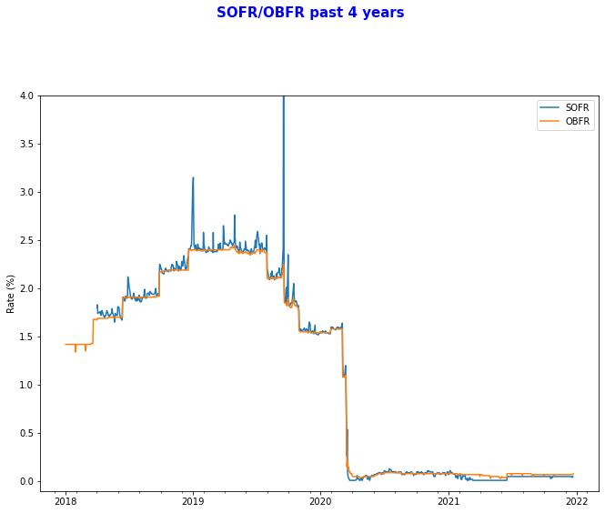

```python
Plot.two(frb_sofr, frb_obfr)
```

Notice that OBFR is not prone to spikes the way SOFR is.

The other thing to notice is that both rates dropped precipitously in early 2020. Note what happened on March 16

```python
frb_obfr.query_data('2020-03-11', '2020-03-17')
```

| date | rate | volume |
| --- | --- | --- |
| 2020-03-12 | 1.10 | 152 |
| 2020-03-13 | 1.10 | 153 |
| 2020-03-16 | 0.15 | 186 |
| 2020-03-17 | 0.20 | 201 |

This of course was due to the economic turmoil caused when the pandemic reaching the United States in early March. In an emergency meeting held Sunday March 15, the Federal Open Market Committee [cut the federal funds](https://www.pnc.com/content/dam/pnc-com/pdf/aboutpnc/EconomicReports/Economic%20Reports/2020/FOMC_03162020.pdf) rate a full percentage point.

Recall the FOMC sets the target rate, and the Federal Reserve uses open market operations to "make" the federal funds effective rate follow the federal funds target rate.

SOFR Term Rates

The CME Group administers 1 Month, 3 Month and 6 Month [term SOFR rates](https://www.cmegroup.com/market-data/cme-group-benchmark-administration/term-sofr.html), that are meant to be more reliable and less volatile than the daily rate.

The CME does not provide free access to the history of these rates.

BGCR and TGCR

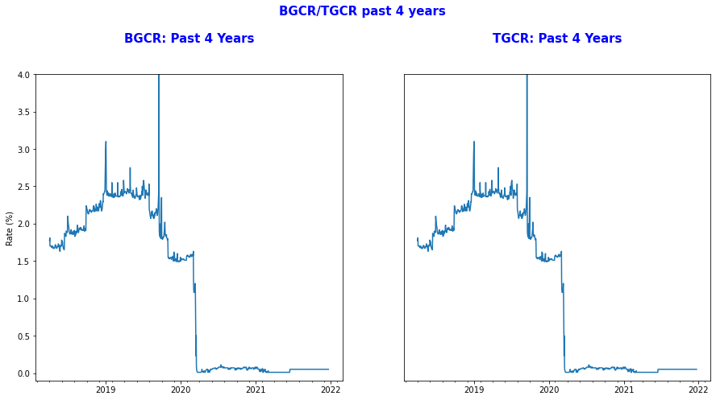

```python
frb_bgcr = NY_FRB(Product.BGCR)
frb_bgcr.get_data()

frb_tgcr = NY_FRB(Product.TGCR)
frb_tgcr.get_data()

Plot.two_side_by_side(frb_bgcr,frb_tgcr)
```

Tri-Party General Collateral Rate (TGCR) is a measure of rates on overnight, specific-counterparty tri-party general collateral repurchase agreement (repo) transactions secured by Treasury securities.

Broad General Collateral Rate (BGCR) is essentially TGCR plus GCF repo transactions.

Just as we saw wutg OBFR and EFFR, BGCR and TGCR are sourced from the same data with minor differences, making the rates seemingly interchangable.

For more information, refer to the FRB of NY web site for [TGCR](https://www.newyorkfed.org/markets/reference-rates/tgcr) and [BGCR](https://www.newyorkfed.org/markets/reference-rates/bgcr)

Shiny App

Lastly, I coded a shiny app with some neat graphical functions. Click [here](https://tbuonora.shinyapps.io/rates/) to see it.